# Simplicity and Depression - K means

# Objective:

To determine if there is a relationship between higher levels of black and white thinking and higher levels of self-reported depression in psychiatric patients hospitalized for depression.Also apply K means clustering and assign groups for model prediction

# Context:

It is common for people who tend to think of their reality as a series of black and white events to suffer from depression. Psybersquare, Inc. describes a few examples of this way of thinking by saying that those who suffer from this way of thinking think that, "If things aren't 'perfect,' then they must be "horrible." If your child isn't "brilliant" then he must be 'stupid.' If you're not 'fascinating' then you must be 'boring.'" This can be a difficult way to live since those suffering from this way of thinking may never feel that their reality is “good enough”.

# Data Sources:

Here, "Black and white thinking" is referred as "Simplicity"

```python
# To enable plotting graphs in Jupyter notebook
%matplotlib inline
```

```python
# Numerical libraries
import numpy as np

from sklearn.model_selection import train_test_split

from sklearn.cluster import KMeans

# to handle data in form of rows and columns
import pandas as pd

# importing ploting libraries
import matplotlib.pyplot as plt

#importing seaborn for statistical plots
import seaborn as sns

from sklearn import metrics

import pandas as pd
```

```python
# reading the CSV file into pandas dataframe
mydata = pd.read_csv("Depression.csv")
```

```python
mydata.head()
```

|  | id | simplicity | fatalism | depression | adjsimp | adjfatal | adjdep |
| --- | --- | --- | --- | --- | --- | --- | --- |
| 0 | 1 | 0.92983 | 0.35589 | 0.59870 | 0.75934 | 0.10673 | 0.41865 |
| 1 | 2 | 0.91097 | 1.18439 | 0.72787 | 0.72717 | 0.99915 | 0.51688 |
| 2 | 3 | 0.53366 | -0.05837 | 0.53411 | 0.62176 | 0.03811 | 0.70699 |
| 3 | 4 | 0.74118 | 0.35589 | 0.56641 | 0.83522 | 0.42218 | 0.65639 |
| 4 | 5 | 0.53366 | 0.77014 | 0.50182 | 0.47697 | 0.81423 | 0.53518 |

```python
##Remove id since it is redundant
mydata.drop('id', axis=1, inplace=True)
```

```python
mydata.info()
```

```
<class 'pandas.core.frame.DataFrame'>
RangeIndex: 82 entries, 0 to 81
Data columns (total 6 columns):
simplicity    82 non-null float64
fatalism      82 non-null float64
depression    82 non-null float64
adjsimp       82 non-null float64
adjfatal      82 non-null float64
adjdep        82 non-null float64
dtypes: float64(6)
memory usage: 3.9 KB
```

```python
mydata.describe().transpose()
```

|  | count | mean | std | min | 25% | 50% | 75% | max |
| --- | --- | --- | --- | --- | --- | --- | --- | --- |
| simplicity | 82.0 | 1.000000 | 0.500000 | 0.25068 | 0.656282 | 0.882665 | 1.26940 | 2.85408 |
| fatalism | 82.0 | 1.000000 | 0.500001 | -0.05837 | 0.563010 | 0.977270 | 1.39152 | 2.22003 |
| depression | 82.0 | 1.000001 | 0.500000 | 0.46953 | 0.566410 | 0.824750 | 1.37373 | 2.24565 |
| adjsimp | 82.0 | 1.000000 | 0.499999 | 0.23569 | 0.697958 | 0.968490 | 1.20179 | 2.94977 |
| adjfatal | 82.0 | 1.000000 | 0.500000 | 0.03012 | 0.731598 | 0.924290 | 1.29912 | 2.24931 |
| adjdep | 82.0 | 1.000000 | 0.500000 | 0.23454 | 0.596565 | 0.967845 | 1.26175 | 2.78763 |

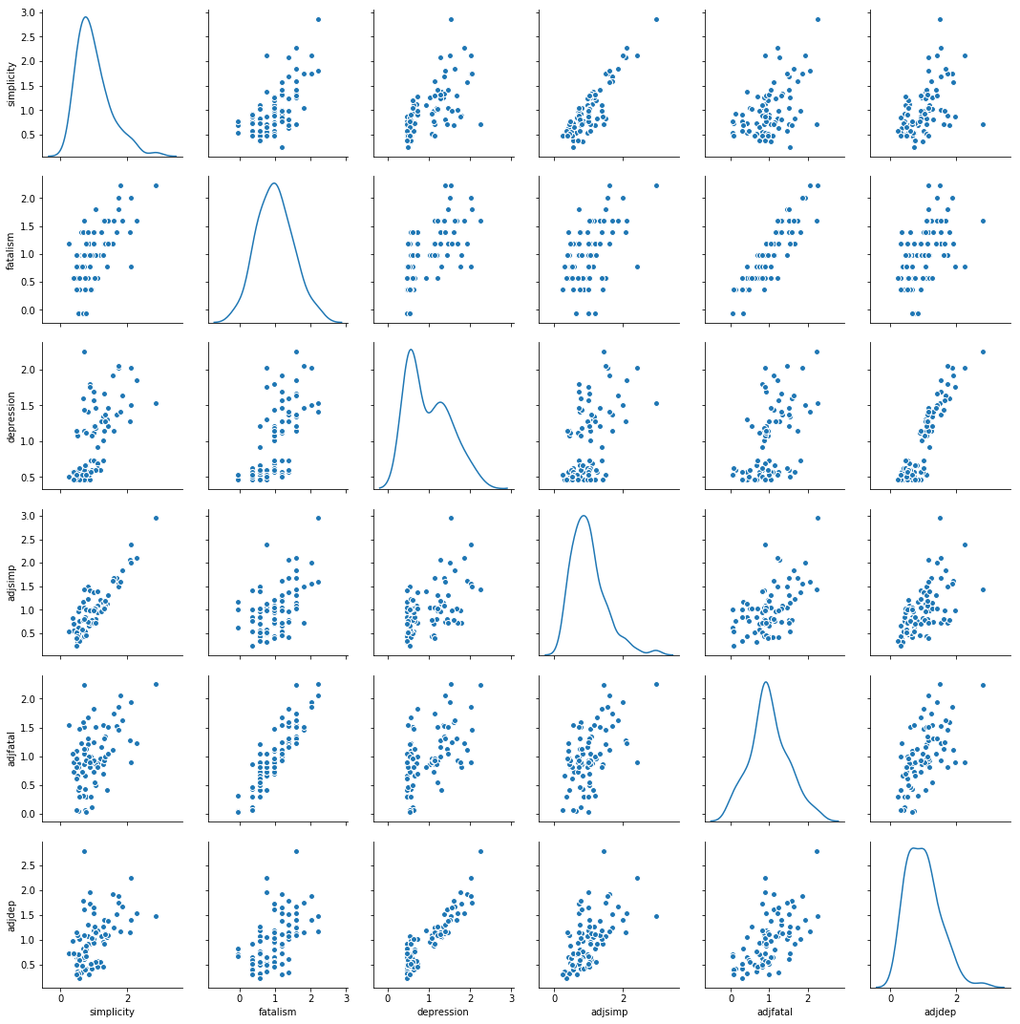

```python
import seaborn as sns
sns.pairplot(mydata, diag_kind='kde')
```

```python
##Based on the kde plots, we can work with 2 or 3 clusters
```

```python
##Scale the data
from scipy.stats import zscore

mydata_z = mydata.apply(zscore)
```

```
Text(0.5,1,'Selecting k with the Elbow Method')
```

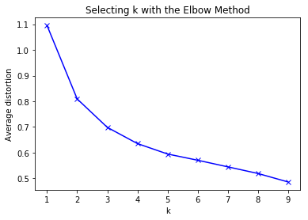

```python
#Finding optimal no. of clusters
from scipy.spatial.distance import cdist
clusters=range(1,10)
meanDistortions=[]

for k in clusters:
    model=KMeans(n_clusters=k)
    model.fit(mydata)
    prediction=model.predict(mydata)
    meanDistortions.append(sum(np.min(cdist(mydata, model.cluster_centers_, 'euclidean'), axis=1)) / mydata
                           .shape[0])


plt.plot(clusters, meanDistortions, 'bx-')
plt.xlabel('k')
plt.ylabel('Average distortion')
plt.title('Selecting k with the Elbow Method')
```

```python
#Set the value of k=3
kmeans = KMeans(n_clusters=3, n_init = 15, random_state=2345)
```

```python
kmeans.fit(mydata_z)
```

```
KMeans(algorithm='auto', copy_x=True, init='k-means++', max_iter=300,
    n_clusters=3, n_init=15, n_jobs=1, precompute_distances='auto',
    random_state=2345, tol=0.0001, verbose=0)
```

```python
centroids = kmeans.cluster_centers_
```

```python
centroids
```

```
array([[-0.00240129,  0.30593064,  0.47588456, -0.15570731,  0.21543758,
         0.41698529],
       [-0.60393647, -0.72164273, -0.90062454, -0.48447657, -0.63244733,
        -0.83635699],
       [ 1.72480697,  1.30084619,  1.39190785,  1.7621744 ,  1.26973449,
         1.35397533]])
```

```python
#Clculate the centroids for the columns to profile
centroid_df = pd.DataFrame(centroids, columns = list(mydata_z) )
```

```python
print(centroid_df)
```

```
   simplicity  fatalism  depression   adjsimp  adjfatal    adjdep
0   -0.002401  0.305931    0.475885 -0.155707  0.215438  0.416985
1   -0.603936 -0.721643   -0.900625 -0.484477 -0.632447 -0.836357
2    1.724807  1.300846    1.391908  1.762174  1.269734  1.353975
```

#### Cluster 1 has the lowest values and cluster 2 has the highest values

```python
## creating a new dataframe only for labels and converting it into categorical variable
df_labels = pd.DataFrame(kmeans.labels_ , columns = list(['labels']))

df_labels['labels'] = df_labels['labels'].astype('category')
```

```python
# Joining the label dataframe with the data frame.
df_labeled = mydata.join(df_labels)
```

```python
df_analysis = (df_labeled.groupby(['labels'] , axis=0)).head(4177)  # the groupby creates a groupeddataframe that needs
# to be converted back to dataframe.
df_analysis
```

|  | simplicity | fatalism | depression | adjsimp | adjfatal | adjdep | labels |
| --- | --- | --- | --- | --- | --- | --- | --- |
| 0 | 0.92983 | 0.35589 | 0.59870 | 0.75934 | 0.10673 | 0.41865 | 1 |
| 1 | 0.91097 | 1.18439 | 0.72787 | 0.72717 | 0.99915 | 0.51688 | 1 |
| 2 | 0.53366 | -0.05837 | 0.53411 | 0.62176 | 0.03811 | 0.70699 | 1 |
| 3 | 0.74118 | 0.35589 | 0.56641 | 0.83522 | 0.42218 | 0.65639 | 1 |
| 4 | 0.53366 | 0.77014 | 0.50182 | 0.47697 | 0.81423 | 0.53518 | 1 |
| 5 | 0.62799 | 1.39152 | 0.56641 | 0.40664 | 1.23261 | 0.34042 | 1 |
| 6 | 0.77891 | 0.35589 | 0.46953 | 0.84556 | 0.29789 | 0.42168 | 1 |
| 7 | 0.83550 | 0.56301 | 0.53411 | 1.49961 | 1.20366 | 1.08127 | 1 |
| 8 | 0.51480 | 0.77014 | 0.46953 | 0.31082 | 0.65651 | 0.36337 | 1 |
| 9 | 0.87323 | 0.35589 | 0.46953 | 1.40836 | 0.85391 | 0.91711 | 1 |
| 10 | 0.53366 | 0.56301 | 0.46953 | 0.43378 | 0.41506 | 0.32811 | 1 |
| 11 | 0.74118 | 0.35589 | 0.63099 | 0.53485 | 0.06531 | 0.41100 | 1 |
| 12 | 0.68458 | -0.05837 | 0.46953 | 1.17308 | 0.30413 | 0.83122 | 1 |
| 13 | 0.47707 | 0.97727 | 0.56641 | 0.42366 | 1.08912 | 0.64871 | 1 |
| 14 | 0.76004 | 0.97727 | 0.66329 | 0.75500 | 1.13055 | 0.79753 | 1 |
| 15 | 0.98643 | 1.39152 | 0.72787 | 1.38099 | 1.82207 | 1.01999 | 0 |
| 16 | 0.36387 | 0.56301 | 0.56641 | 0.82060 | 1.04594 | 0.98004 | 1 |
| 17 | 0.83550 | 1.18439 | 0.56641 | 1.23164 | 1.67146 | 0.92942 | 0 |
| 18 | 0.55253 | 0.77014 | 0.59870 | 0.49834 | 0.81423 | 0.64106 | 1 |
| 19 | 0.38274 | 0.56301 | 0.56641 | 0.55240 | 0.73050 | 0.70702 | 1 |
| 20 | 0.53366 | 0.56301 | 0.46953 | 0.96973 | 0.88023 | 0.70239 | 1 |
| 21 | 0.70345 | 1.39152 | 0.59870 | 0.77089 | 1.50663 | 0.60579 | 0 |
| 22 | 1.11848 | 0.97727 | 0.69558 | 1.09622 | 0.88198 | 0.57515 | 1 |
| 23 | 0.74118 | 0.56301 | 0.66329 | 0.83522 | 0.65564 | 0.76227 | 1 |
| 24 | 0.57139 | 0.97727 | 0.63099 | 1.04486 | 1.47144 | 1.00768 | 0 |
| 25 | 0.70345 | 0.77014 | 0.46953 | 1.03886 | 1.03883 | 0.65177 | 1 |
| 26 | 0.47707 | 0.56301 | 0.46953 | 0.52526 | 0.61421 | 0.50757 | 1 |
| 27 | 0.57139 | 0.35589 | 0.50182 | 0.75529 | 0.45561 | 0.59349 | 1 |
| 28 | 0.64685 | 0.77014 | 0.53411 | 0.58359 | 0.73138 | 0.48458 | 1 |
| 29 | 0.85437 | 1.18439 | 0.53411 | 0.66306 | 0.99915 | 0.30513 | 1 |
| ... | ... | ... | ... | ... | ... | ... | ... |
| 52 | 1.59011 | 1.59865 | 1.14768 | 1.67363 | 1.74808 | 1.24102 | 2 |
| 53 | 0.77891 | 1.18439 | 1.11539 | 0.45440 | 0.92429 | 0.88975 | 0 |
| 54 | 1.23167 | 1.39152 | 1.27685 | 0.96725 | 1.15775 | 1.06621 | 0 |
| 55 | 1.34487 | 1.59865 | 1.37373 | 1.08467 | 1.34978 | 1.12914 | 0 |
| 56 | 0.47707 | 0.97727 | 1.14768 | 0.39127 | 0.96484 | 1.15513 | 0 |
| 57 | 1.30714 | 1.18439 | 1.14768 | 1.05273 | 0.92429 | 0.92504 | 0 |
| 58 | 1.42033 | 1.59865 | 1.21227 | 1.31493 | 1.50750 | 1.08920 | 0 |
| 59 | 1.32600 | 1.18439 | 1.27685 | 1.19729 | 0.99915 | 1.11684 | 0 |
| 60 | 1.09962 | 0.56301 | 0.92163 | 1.38602 | 0.81336 | 1.18111 | 0 |
| 61 | 1.02416 | 0.56301 | 1.21227 | 1.02177 | 0.53934 | 1.26866 | 0 |
| 62 | 0.89210 | 0.97727 | 1.79354 | 0.71660 | 0.80712 | 1.72445 | 0 |
| 63 | 1.00529 | 1.18439 | 1.69666 | 0.71083 | 0.92429 | 1.52500 | 0 |
| 64 | 2.85408 | 2.22003 | 1.53520 | 2.94977 | 2.24931 | 1.48506 | 2 |
| 65 | 0.68458 | 1.39152 | 1.59979 | 0.77111 | 1.58948 | 1.78573 | 0 |
| 66 | 2.11834 | 2.01290 | 1.50291 | 1.99319 | 1.94099 | 1.39914 | 2 |
| 67 | 1.57125 | 1.18439 | 1.92272 | 1.60907 | 1.11544 | 1.91624 | 2 |
| 68 | 1.74104 | 2.01290 | 2.01960 | 1.54422 | 1.85813 | 1.87792 | 2 |
| 69 | 0.87323 | 0.77014 | 1.76125 | 0.98480 | 0.88910 | 1.96219 | 0 |
| 70 | 0.72231 | 1.59865 | 2.24565 | 1.44060 | 2.23870 | 2.78763 | 2 |
| 71 | 1.74104 | 1.80577 | 2.05189 | 1.50102 | 1.45896 | 1.74144 | 2 |
| 72 | 0.81664 | 1.39152 | 1.40603 | 0.74352 | 1.30748 | 1.30863 | 0 |
| 73 | 1.30714 | 1.59865 | 1.66437 | 1.03113 | 1.30835 | 1.40382 | 0 |
| 74 | 0.70345 | 0.97727 | 1.43832 | 0.79248 | 1.12256 | 1.60927 | 0 |
| 75 | 1.85423 | 1.59865 | 1.63208 | 1.83881 | 1.63178 | 1.67682 | 2 |
| 76 | 2.26926 | 1.59865 | 1.85813 | 2.09935 | 1.22550 | 1.52969 | 2 |
| 77 | 1.04302 | 1.80577 | 1.47061 | 0.72117 | 1.50039 | 1.14913 | 0 |
| 78 | 1.79763 | 2.22003 | 1.40603 | 1.59752 | 2.05016 | 1.16443 | 2 |
| 79 | 2.11834 | 0.77014 | 2.01960 | 2.39515 | 0.88910 | 2.24452 | 2 |
| 80 | 1.42033 | 1.18439 | 1.47061 | 1.31493 | 1.04058 | 1.37153 | 0 |
| 81 | 0.98643 | 1.18439 | 1.56749 | 0.97903 | 1.23973 | 1.65687 | 0 |

82 rows × 7 columns

```python
df_labeled['labels'].value_counts()
```

```
1    37
0    32
2    13
Name: labels, dtype: int64
```

```python
from mpl_toolkits.mplot3d import Axes3D
```

```
Text(0.5,0.92,'3D plot of KMeans Clustering')
```

[figure not shown]

```python
## 3D plots of clusters
fig = plt.figure(figsize=(8, 6))
ax = Axes3D(fig, rect=[0, 0, .95, 1], elev=20, azim=60)
kmeans.fit(mydata_z)
labels = kmeans.labels_
ax.scatter(mydata_z.iloc[:, 0], mydata_z.iloc[:, 1], mydata_z.iloc[:, 3],c=labels.astype(np.float), edgecolor='k')
ax.w_xaxis.set_ticklabels([])
ax.w_yaxis.set_ticklabels([])
ax.w_zaxis.set_ticklabels([])
ax.set_xlabel('Length')
ax.set_ylabel('Height')
ax.set_zlabel('Weight')
ax.set_title('3D plot of KMeans Clustering')
```

```python
# Let us try with K = 2
final_model=KMeans(2)
final_model.fit(mydata)
prediction=final_model.predict(mydata)

#Append the prediction
mydata["GROUP"] = prediction
print("Groups Assigned : \n")
mydata[["depression", "GROUP"]]
```

```
Groups Assigned :
```

|  | depression | GROUP |
| --- | --- | --- |
| 0 | 0.59870 | 1 |
| 1 | 0.72787 | 1 |
| 2 | 0.53411 | 1 |
| 3 | 0.56641 | 1 |
| 4 | 0.50182 | 1 |
| 5 | 0.56641 | 1 |
| 6 | 0.46953 | 1 |
| 7 | 0.53411 | 1 |
| 8 | 0.46953 | 1 |
| 9 | 0.46953 | 1 |
| 10 | 0.46953 | 1 |
| 11 | 0.63099 | 1 |
| 12 | 0.46953 | 1 |
| 13 | 0.56641 | 1 |
| 14 | 0.66329 | 1 |
| 15 | 0.72787 | 0 |
| 16 | 0.56641 | 1 |
| 17 | 0.56641 | 1 |
| 18 | 0.59870 | 1 |
| 19 | 0.56641 | 1 |
| 20 | 0.46953 | 1 |
| 21 | 0.59870 | 1 |
| 22 | 0.69558 | 1 |
| 23 | 0.66329 | 1 |
| 24 | 0.63099 | 1 |
| 25 | 0.46953 | 1 |
| 26 | 0.46953 | 1 |
| 27 | 0.50182 | 1 |
| 28 | 0.53411 | 1 |
| 29 | 0.53411 | 1 |
| ... | ... | ... |
| 52 | 1.14768 | 0 |
| 53 | 1.11539 | 1 |
| 54 | 1.27685 | 0 |
| 55 | 1.37373 | 0 |
| 56 | 1.14768 | 1 |
| 57 | 1.14768 | 1 |
| 58 | 1.21227 | 0 |
| 59 | 1.27685 | 0 |
| 60 | 0.92163 | 1 |
| 61 | 1.21227 | 1 |
| 62 | 1.79354 | 0 |
| 63 | 1.69666 | 0 |
| 64 | 1.53520 | 0 |
| 65 | 1.59979 | 0 |
| 66 | 1.50291 | 0 |
| 67 | 1.92272 | 0 |
| 68 | 2.01960 | 0 |
| 69 | 1.76125 | 0 |
| 70 | 2.24565 | 0 |
| 71 | 2.05189 | 0 |
| 72 | 1.40603 | 0 |
| 73 | 1.66437 | 0 |
| 74 | 1.43832 | 0 |
| 75 | 1.63208 | 0 |
| 76 | 1.85813 | 0 |
| 77 | 1.47061 | 0 |
| 78 | 1.40603 | 0 |
| 79 | 2.01960 | 0 |
| 80 | 1.47061 | 0 |
| 81 | 1.56749 | 0 |

82 rows × 2 columns

[output not shown]

[figure not shown]

```python
#plt.cla()

import matplotlib.cm as cm



colors = cm.rainbow(np.linspace(0, 1, 2))


#plt.scatter(mydata["simplicity"][mydata.GROUP==0],
             #mydata["simplicity"][mydata.GROUP==1],c = colors, alpha=0.5)

plt.scatter(mydata["simplicity"][mydata.GROUP==0],
             mydata["depression"][mydata.GROUP==1],c = colors, alpha=0.5)
```

```
array([[<matplotlib.axes._subplots.AxesSubplot object at 0x000001D12C6696A0>,
      dtype=object)
```

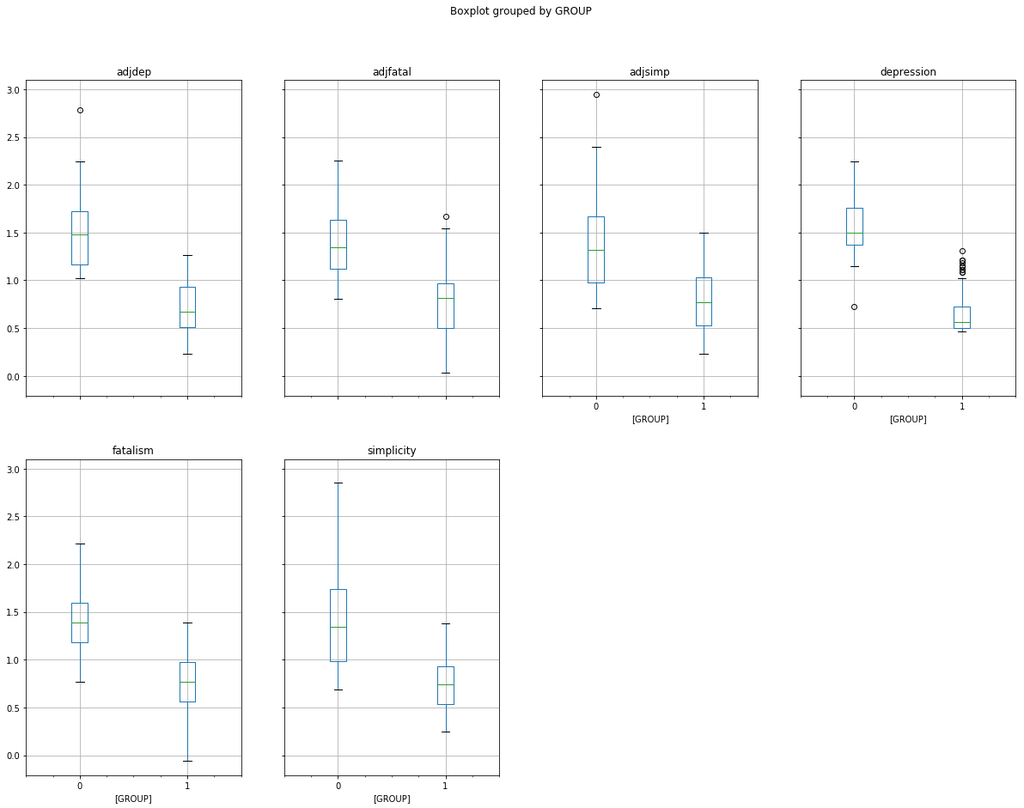

```python
#plt.scatter(mydata["simplicity"][mydata.GROUP==0],
             #mydata["simplicity"][mydata.GROUP==1],c = colors, alpha=0.5)



mydata.boxplot(by = 'GROUP',  layout=(2,4), figsize=(20, 15))
```

```python
# 2 clusters gives a clear separation of high and low values
```

```python
#To determine if a relationship exists between black and white thinking(simplicity) and depression.
mydata['simplicity'].corr(mydata['depression'])
```

```
0.6432667885861313
```

The correlation coefficient above indicates that the relationship between black and white thinking and depression can be considered moderate and positive. This means that we can see a clear relationship between black and white thinking and Depression, although the relationship is not perfect. The fact that the correlation coefficient is positive, indicates that higher levels of black and white thinking is associated with higher levels of depression

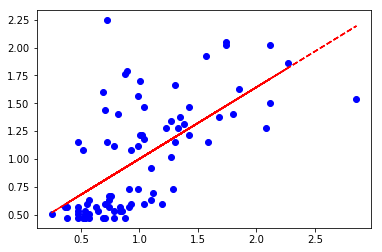

```python
%matplotlib inline
import pandas as pd
plt.plot(mydata['simplicity'], mydata['depression'], 'bo')
z = np.polyfit(mydata['simplicity'], mydata['depression'],1)
p = np.poly1d(z)
plt.plot(mydata['simplicity'], p(mydata['simplicity']), "r--")

#geom_point()
```

```python
# As you can see from the above graphic, although the data does not form a perfectly straight line, it does fall in a way that
#indicates a positive relationship. Therefore, we can once again conclude that there is a relationship between black and white
#thinking and depression. It is important to note, however, that correlation does not in any way indicate causality and is merely
#indicative of a relationship between the two.
```